# STAT COMPUTAZIONALE LEZ 4

Valerio Calà

11/9/2019

## BOOTSTRAP

Si tratta di una tecnica introdotta a fine anni ’70 con cui calcolare il valore atteso, varianza o altre proprietà (PARAMETRO THETA) di uno stimatore o di una procedura statistica, quando la risoluzione analitica non è agevole.

L’idea generale è quella di fare inferenza con simulazioni in ambito frequentista (RICAMPIONAMENTO dall’unico campione x a disposizione; campionamento casuale semplice, i.e. *estrazioni con reinserimento*).

Sui B-campioni ottenuti si calcola la stima di theta (se theta=varianza, si calcola la varianza campionaria ecc.) e si prende la media sui B valori come stima finale (*Bootstrap Estimate*).

```r
x <- c(28,-44, 29, 30, 24, 28, 37, 32, 36, 27, 26, 28, 29, 26, 27, 22, 23, 20, 25, 25, 36, 23, 31, 32, 24, 27, 33, 16, 24, 29, 36, 21, 28, 26, 27, 27, 32, 25, 28, 24, 40, 21, 31, 32, 28, 26, 30, 27, 26, 24, 32, 29, 34, -2, 25, 19, 36, 29, 30, 22, 28, 33, 39, 25, 16, 23
)

bootstrap <- function(data, B, theta, ...) {
    z <- list()
  # genero x1,...,xB campioni a partire dal campione x
  datas <- matrix(sample(data, size=length(data)*B, replace=T),nrow=B)
  # calcolo theta(x1), ..., theta(xB)
  B.estimate <- apply(datas, 1, theta, ...)
  # calcolo theta(x) stima classica
  z$est <- theta(data, ...)
  z$distn <- B.estimate
  # stima del Bias (distorsione delle stime bootstrap)
  z$bias <- mean(B.estimate) - z$est
  z$sd <- sd(B.estimate)
  z
}

# vogliamo stimare la tendenza centrale
# considera 2 stimatori: media e media troncata con alpha=.05

mean.b <- bootstrap(data=x, B=1000, theta=mean)
df1 <- data.frame(media=mean.b$est, bias=mean.b$bias, sd=mean.b$sd)
df1
```

```
##      media        bias     sd
## 1 26.21212 -0.04578788 1.2933
```

```r
trigger.mean.b <- bootstrap(data=x, B=1000, theta=mean, trim=.05)
df2 <- data.frame(media.trigger=trigger.mean.b$est, bias=trigger.mean.b$bias, sd=trigger.mean.b$sd)
df2
```

```
##   media.trigger        bias       sd
## 1          27.4 -0.08466667 0.802616
```

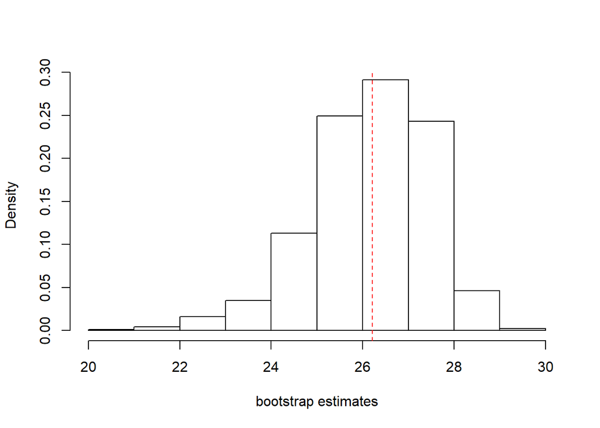

```r
hist(mean.b$distn, freq=F, xlab='bootstrap estimates', main='')
abline(v=mean.b$est, col='red', lty=2)
```

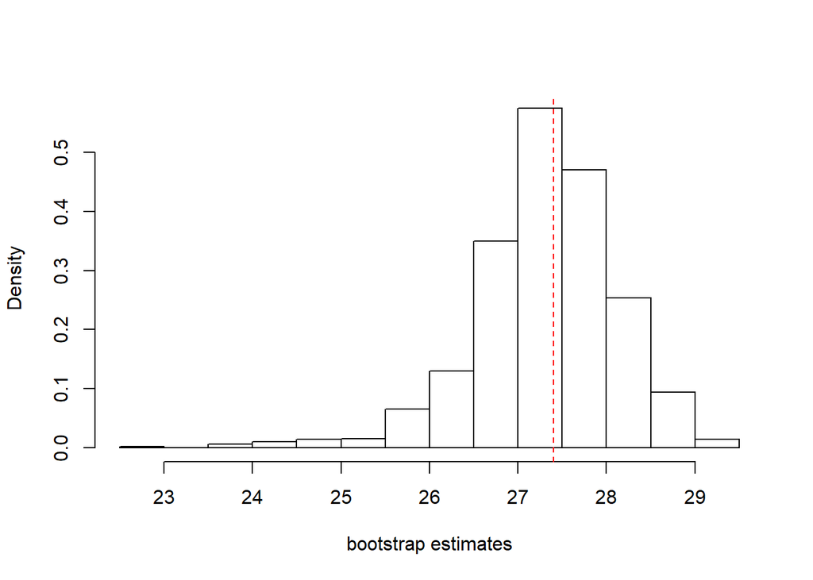

```r
hist(trigger.mean.b$distn, freq=F, xlab='bootstrap estimates', main='')
abline(v=trigger.mean.b$est, col='red', lty=2)
```

**Tema d’esame**: generare un campione di 20 valori casuali da una *Gamma(4,10)* con seme dell’estrazione 127. Calcola per il parametro media (=alpha/beta) una stima bootstrap e costruisci un intervallo di confidenza bootstrap base di livello 95%.

```r
set.seed(127)
n = 20
x <- rgamma(n, 4, 10)
m <- 4/10
# genero B=200 campioni a partire da x
B = 200
datas <- matrix(data=sample(x, size=length(x)*B, replace=T), nrow=B)
# stime
m.est <- mean(x)                  # classica
m.distn <- apply(datas, 1, mean)  # B stime
m.bias <- mean(m.distn) - m.est   # bias
m.sd <- sd(m.distn)               # sqrt(varianza campionaria B)

# se la distorsione/(standard error) è < 0.25 non è necessario usare metodi per ridurre la distorsione
m.bias/m.sd <= 0.25
```

```
## [1] TRUE
```

```r
# costruisco IC di livello 95% per theta=media di una Gamma(4,10)
# 1 - 2*alpha = 0.95 -> alpha = 0.05/2 = 0.025
# estraggo da Gamma(4,10) i quantili di livello 0.975,0.025
quantiles <- c(qgamma(p=0.975, 4, 10), qgamma(p=0.025, 4, 10))
IC <- c(m.est - m.sd*quantiles[1], m.est - m.sd*quantiles[2])

# l'IC include la vera media
df <- data.frame(media.vera=4/10, media.stimata=m.est, lower.bound=IC[1], upper.bound=IC[2]); df
```

```
##   media.vera media.stimata lower.bound upper.bound
## 1        0.4     0.4373786   0.3951094   0.4321241
```

Il Bootstrap può essere utilizzato anche in ambito di regressione e modelli lineari generalizzati. Si usa il pacchetto *boot* con l’omonima funzione, che prevede 3 argomenti: il primo è il dataframe su cui lavoriamo, il secondo è il modello lineare (generalizzato) che vogliamo implementare con indici per le unità ricampionate, il terzo è il numero di ricampionamenti B. Per fornire il secondo argomento dobbiamo quindi fare uno step intermedio e creare una funzione bootstrap customizzata, funzione dei dati e degli indici.

**Esempio 1** : Un certo dispositivo medico atto a rilasciare un certo ormone antinﬁammatorio nel corpo in modo continuo nel tempo è stato testato su 27 soggetti. Ai soggetti è stato casualmente assegnato un dispositivo proveniente da uno di tre lotti (**Lot**).E’ stato poi misurato l’ammontare di ormone rimanente (**amount**) nel dispositivo dopo averlo indossato per un determinato periodo di tempo (**hours**).

```r
library(bootstrap)
library(boot)
library(MASS)
data(hormone)
set.seed(123); B = 1000

# inferenza classica
hormone.lm <- lm(amount ~ 0 + Lot + hrs, data=hormone)
coef(hormone.lm)
```

```
##        LotA        LotB        LotC         hrs
## 32.13159495 36.10509461 35.59732433 -0.06013605
```

```r
# bootstrap sulle unità statistiche (x,y) , x=c(Lot, hrs)
# bootstrap statistic : function of data
boot.lm <- function(data, index) {
  data <- data[index,]
  mod <- lm(amount ~ 0 + Lot + hrs, data=data)
  coef(mod)
}

bootstrap.hormone <- boot(data=hormone, statistic=boot.lm, R=B)
bootstrap.hormone
```

```
##
## ORDINARY NONPARAMETRIC BOOTSTRAP
##
##
## Call:
## boot(data = hormone, statistic = boot.lm, R = B)
##
##
## Bootstrap Statistics :
##        original        bias    std. error
## t1* 32.13159495  0.0435835807  0.76888509
## t2* 36.10509461  0.1834510547  1.21962760
## t3* 35.59732433  0.0604831462  0.62038195
## t4* -0.06013605 -0.0004758288  0.00395957
```

```r
# per ridurre il bias posso applicare la correzione
# theta.BIAS.CORRECTED = 2theta - bootstrap.estimate

BC <- 2*coef(hormone.lm)[2] - (1/B)*sum(bootstrap.hormone$t[1001:2000])

new.bias <- coef(hormone.lm)[2] - BC
new.bias
```

```
##      LotB
## 0.1834511
```

```r
#plot(bootstrap.hormone, index=1)
#plot(bootstrap.hormone, index=2)
#plot(bootstrap.hormone, index=3)
#plot(bootstrap.hormone, index=4)

#head(boot.array(bootstrap.hormone), n=5)

# bootstrap sui residui (bias minore se modello correttamente specificato; meno robusto della variante sulle unità statistiche)

fit <- fitted(hormone.lm)

e <- residuals(hormone.lm)

X <- model.matrix(hormone.lm)
boot.lm.res <- function(data, index) {
  y = fit + e[index]
  mod = lm(y ~ X - 1)
  coef(mod)
}

boot(data=hormone, statistic=boot.lm.res, R=B)
```

```
##
## ORDINARY NONPARAMETRIC BOOTSTRAP
##
##
## Call:
## boot(data = hormone, statistic = boot.lm.res, R = B)
##
##
## Bootstrap Statistics :
##        original        bias    std. error
## t1* 32.13159495 -0.0076871101 0.701040512
## t2* 36.10509461  0.0069272759 0.909694907
## t3* 35.59732433 -0.0072456100 0.564658786
## t4* -0.06013605  0.0000594167 0.003212912
```

**Esempio 2** : E’ stato condotto un esperimento in cui un diverso numero di scarafaggi (**m**) è stato esposto a diverse dosi del veleno (**ldose**, in scala logaritmica), registrando poi il numero di scarafaggi morti a ciascun dosaggio (**r**). Il numero di decessi è funzione delle dosi del veleno e si distribuisce come una binomiale (**family binomial**) con size m e probabilità p=G(a+b*ldose), dove G è una funzione di ripartizione continua.  
1.Normale **probit**  
2.Logistica **logit**  
3.a valori estremi **complementary log-log**

```r
# obiettivo: trovare il valore di dose (in scala logaritmica)
#             t.c. il 50% della popolazione di scarafaggi muore.
X <- matrix(data=c(59, 6, 1.6907, 60, 13, 1.7242, 62, 18, 1.7552, 56, 28, 1.7842, 63, 52, 1.8113, 59, 53, 1.8369, 62, 61, 1.8610, 60, 60, 1.8839), ncol=3, byrow=T)

X <- data.frame(m=X[,1], r=X[,2], ldose=X[,3])

# inferenza classica
# G(a + b*x50) = 0.5; G probit (cdf N)
# x50 = (G^-1(0.5) - aGLS)/bGLS
mod <- glm(cbind(r, m-r) ~ ldose, data=X, family=binomial(link='probit'))
xp <- dose.p(mod, p=0.5) #p=0.5 default value
xp
```

```
##              Dose          SE
## p = 0.5: 1.770852 0.003803312
```

```r
# bootstrap
boot.glm <- function(data, index) {
data <- data[index,]
mod <- glm(cbind(r, m-r) ~ ldose, data=data,family=binomial(link='probit'))
dose.p(mod)
}

boot.estimate <- boot(data=X, statistic=boot.glm, R=1000)
boot.estimate
```

```
##
## ORDINARY NONPARAMETRIC BOOTSTRAP
##
##
## Call:
## boot(data = X, statistic = boot.glm, R = 1000)
##
##
## Bootstrap Statistics :
##     original       bias    std. error
## t1* 1.770852 0.0003508581 0.005340713
```

```r
# il bias è 4*10^-4 (praticamente nullo)
# lo SE è superiore rispetto alla stima classica
```

## JACKKNIFE

Dato un campione **x** d’ampiezza **n**, definiamo l’i-esimo campione *JackKnife* come x[-i] d’ampiezza n-1 (rimuovo semplicemente l’i-esima unità di x).  
Su ciascun campione *JackKnife* viene calcolato lo stimatore d’interesse e, al solito, si prende la media degli **n valori** (non più B, user-specified) così calcolati.

Le stime della distorsione e della varianza dello stimatore vengono corrette per un fattore moltiplicativo (n-1) che tiene conto del fatto che i campioni *JackKnife* sono molto simili tra loro.

```r
# esempio: stima MEDIA e DEV.STD dei tempi di sopravvivenza dopo un intervento

x <- c(94,197,16,38,99,141,23)
media <- mean(x)
dev.std <- sd(x)/sqrt(length(x))

# jacknife
require(bootstrap)

theta <- function(x) {mean(x)}
results <- jackknife(x, theta)
c(media, mean(results$jack.values))
```

```
## [1] 86.85714 86.85714
```

```r
c(dev.std, results$jack.se)
```

```
## [1] 25.23549 25.23549
```

```r
results$jack.bias
```

```
## [1] 0
```

Per concludere il JackKnife si può vedere come un’approssimazione del BootStrap, computazionalmente molto meno onerosa (se n è inferiore a B), però meno efficiente (soprattutto in caso di stimatori non lineari nei dati).